# Unsupervised Learning on Spatial Transcriptomics Data

Alex Li

July 25th, 2022

```r
library(spacexr)
library(Matrix)
```

## Introduction

Reference-free Inference of Cell types and Expression, or RICE, is an unsupervised statistical method for learning cell types and gene expression profiles from spatial transcriptomics data. In this vignette, we will assign cell types to a cerebellum Slide-seq dataset without the use of an outside reference.

## Data Preproessing

We begin by loading the spatial transcriptomics data into a `SpatialRNA` object. More details about this process is located on our vignette on [applying RCTD to a spatial transcriptomics dataset](https://raw.githack.com/dmcable/spacexr/master/vignettes/spatial-transcriptomics.html).

```r
datadir <- system.file("extdata",'SpatialRNA/Vignette',package = 'spacexr') # directory for sample Slide-seq dataset
counts <- read.csv(file.path(datadir,"MappedDGEForR.csv")) # load in counts matrix
coords <- read.csv(file.path(datadir,"BeadLocationsForR.csv"))
rownames(counts) <- counts[,1]; counts[,1] <- NULL # Move first column to rownames
rownames(coords) <- coords$barcodes; coords$barcodes <- NULL # Move barcodes to rownames
nUMI <- colSums(counts) # In this case, total counts per pixel is nUMI

### Create SpatialRNA object
puck <- SpatialRNA(coords, counts, nUMI)
```

## Creating RCTD Object

Like all other methods in spacexr, we begin by creating an `RCTD` object. Since no reference is required, we use the `create.RCTD.noref` function, which instead requires a gene-expression profile initialization in the form of a `cell_type_info` list object used in RCTD. While this can be random or pre-computed, we provide the `initialize.clusters` function that computes the initialization from Seurat clustering on the spatial dataset and is what we recommend. This function returns a `cell_type_info` list that can be directly passed into `create.RCTD.noref`. Most other configuration options are the same as for the `create.RCTD` function.

```r
cell_type_info <- initialize.clusters(puck, resolution = 1.2)
```

```
#> Begin: initialize.clusters
#> Warning: Invalid name supplied, making object name syntactically valid. New
#> object name is Seurat..SCTransform.Spatial; see ?make.names for more details on
#> syntax validity
#> Warning in irlba(A = t(x = object), nv = npcs, ...): You're computing too large
#> a percentage of total singular values, use a standard svd instead.
#> End: initialize.clusters, 6 clusters generated
```

```r
myRCTD <- create.RCTD.noref(puck, cell_type_info, max_cores = 4)
```

```
#> create.RCTD.unsupervised: getting regression differentially expressed genes:
#> get_de_genes: 0 found DE genes: 69
#> get_de_genes: 1 found DE genes: 75
#> get_de_genes: 2 found DE genes: 58
#> get_de_genes: 3 found DE genes: 74
#> get_de_genes: 4 found DE genes: 70
#> get_de_genes: 5 found DE genes: 62
#> get_de_genes: total DE genes: 321
```

## Running RICE

We can now run RICE with the `run.RICE` function, which is equivalent to sequentially running the functions `choose_sigma_c` and `iterOptim`. Note that unlike RCTD, we do not need to run `fitBulk` since this approach is reference-free. RICE currently supports running in ‘doublet mode’ and ‘full mode’, but not ‘multi mode’.

```r
RCTDlist <- run.RICE(myRCTD, doublet_mode = 'doublet')
```

```
#> chooseSigma: using initial Q_mat with sigma =  1
#> Likelihood value: 2054.66931635549
#> Sigma value:  1.14
#> Likelihood value: 2052.57681639945
#> Sigma value:  1.12
#> Likelihood value: 2052.44107589108
#> Sigma value:  1.12
#> iterOptim: assigning initial cell types
#> iterOptim: running iteration 1
#> fitting gene profiles
#> run.CSIDE.general: running CSIDE with cell types 0, 1, 2, 3, 4, 5
#> run.CSIDE.general: configure params_to_test = 1,
#> fitting cell types
#> change: 0.186137095966312
#> iterOptim: running iteration 2
#> fitting gene profiles
#> run.CSIDE.general: running CSIDE with cell types 0, 1, 2, 3, 4, 5
#> run.CSIDE.general: configure params_to_test = 1,
#> fitting cell types
#> change: 0.00259618703635172
#> iterOptim: running iteration 3
#> fitting gene profiles
#> run.CSIDE.general: running CSIDE with cell types 0, 1, 2, 3, 4, 5
#> run.CSIDE.general: configure params_to_test = 1,
#> fitting cell types
#> change: 0.00678734876122686
#> iterOptim: running iteration 4
#> fitting gene profiles
#> run.CSIDE.general: running CSIDE with cell types 0, 1, 2, 3, 4, 5
#> run.CSIDE.general: configure params_to_test = 1,
#> fitting cell types
#> change: 0.000269424676564274
```

## RICE Results

By default, `run.RICE` returns a list of RCTD objects for each iteration. The last object in the lists stores the cell type results in `@results`, and the cell type-specific gene expression profiles can be found in `@cell_type_info$info`. As an overview, we will generate several plots produced in our RCTD vignette.

```r
myRCTD <- RCTDlist[[length(RCTDlist)]]
results <- myRCTD@results
norm_weights = normalize_weights(results$weights)
cell_type_names <- myRCTD@cell_type_info$info[[2]] #list of cell type names
spatialRNA <- myRCTD@spatialRNA
resultsdir <- 'RCTD_Plots' ## you may change this to a more accessible directory on your computer.
dir.create(resultsdir)
# make the plots
# Plots the confident weights for each cell type as in full_mode (saved as
# 'results/cell_type_weights_unthreshold.pdf')
plot_weights(cell_type_names, spatialRNA, resultsdir, norm_weights)
```

```r
# Plots all weights for each cell type as in full_mode. (saved as
# 'results/cell_type_weights.pdf')
plot_weights_unthreshold(cell_type_names, spatialRNA, resultsdir, norm_weights)
```

```r
# Plots the weights for each cell type as in doublet_mode. (saved as
# 'results/cell_type_weights_doublets.pdf')
plot_weights_doublet(cell_type_names, spatialRNA, resultsdir, results$weights_doublet,
                     results$results_df)
```

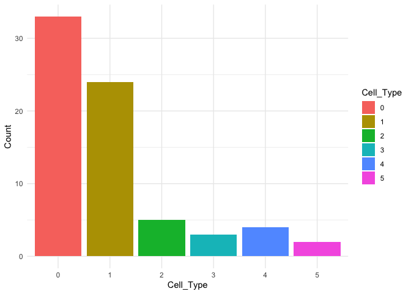

```r
# Plots the number of confident pixels of each cell type in 'full_mode'. (saved as
# 'results/cell_type_occur.pdf')
plot_cond_occur(cell_type_names, resultsdir, norm_weights, spatialRNA)
```

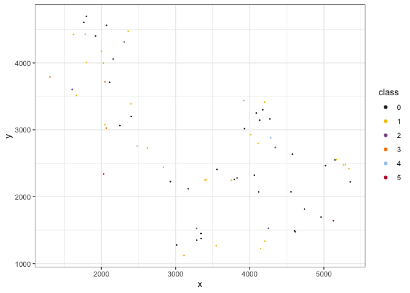

```r
# makes a map of all cell types, (saved as
# 'results/all_cell_types.pdf')
plot_all_cell_types(results$results_df, spatialRNA@coords, cell_type_names, resultsdir)
```